# ProFound-Source-Finding

Aaron Robotham

2017-12-07

## Introduction to ProFound Functions

The **ProFound** source finding and image utilites suite covers the following functions:

### Very High Level

- profoundProFound: Source finder and CoG growing utility (this is what we refer to as ProFound elsewhere, as a short-hand)

### High Level

- profoundMakeSegim: Watershed image segmentation
- profoundMakeSkyGrid: Calculate smoothed (e.g. bicubic) sky maps
- profoundSkyEst: Sky estimator using circular annuli (robust to bright central extended sources)

### Mid Level

- profoundGainEst: Estimate image gain
- profoundGetEllipses: Calculate multiple annulus properties of iso-photal ellipses
- profoundGetEllipsesPlot: Create diagnostic plot of estimated iso-photal ellipses
- profoundMakeSegimDilate: Segmentation map dilation
- profoundMakeSegimExpand: Segmentation map expansion
- profoundMakeSegimPropagate: Propagate segmentation map segments over adjacent sky pixels
- profoundMakeSigma: Make a Sigma Map
- profoundMakeSkyMap: Calculate coarse sky maps
- profoundMakeStack: Create a stacked image
- profoundPixelCorrelation: Calculate pixel-to-pixel correlation and 2D image FFT
- profoundSegimGroup: Find the IDs of groups of touching segments
- profoundSegimMerge: Optimally merge segmentation maps
- profoundSegimNear: Find the IDs of all segments near to other segments
- profoundSegimPlot: Image segmentation plots
- profoundSegimStats: Image segmentation statistics (e.g. flux, apertures etc)
- profoundSkyEstLoc: Local sky estimator using source clipping

### Low Level

- profoundDrawEllipse: Draw Ellipse
- profoundFlux2Mag: Convert from flux to magnitude
- profoundFlux2SB: Convert from flux to surface brightness
- profoundGainConvert: Update gain values when changing zero-points
- profoundGetEllipse: Calculate single annulus properties of an iso-photal ellipse
- profoundGetPixScale: Get Pixel Scale
- profoundImBlur: Fast image blur
- profoundImDiff: Fast image difference
- profoundImGrad: Fast image gradients
- profoundInterp2d: Image interpolation
- profoundMag2Flux: Convert from magnitude to flux
- profoundMag2Mu: Convert from magnitude to central surface brightness
- profoundMu2Mag: Convert from central surface brightness to magnitude
- profoundSB2Flux: Convert from surface brightness to flux

## Basic ProFound Usage

The **profoundProFound** function might be the only function many people need to use in order to extract photometry from a target image. In brief, in fully automatic mode using default option, the basic code flow of the source extraction is as follows:

1. Make a rough sky map
2. Using this rough sky map, make an initial segmentation map
3. Using this segmentation map, make a better sky map
4. Using this better sky map, extract basic photometric properties
5. Using the current segmentation map, dilate segments and re-measure photometric properties for the new image segments (by default it iterates six times)
6. Using the iterative dilation statistics, every object is checked for convergence (by default convergence of flux is used)
7. Make final segmentation map by combining the segments when each source has converged in flux
8. Make a conservative object mask by aggressively dilating the final segmentation map
9. Using this conservative objects mask make a final sky map
10. Using the final segmentation map and the final sky map compute the final comprehensive photometric properties
11. Return a list containing the input image pixel-matched final segmentation map (called **segim**), the pre-dilation segmentation map (**segim_orig**) , the binary object/sky mask (**objects**), the conservatively dilated binary object/sky mask (**objects_redo**), the sky image (**sky**), the sky-RMS image (**skyRMS**) and the effective surface brightness limit image (**SBlim**)
12. Return the data-frame of photometric properties for every detected source (**segstats**)

Some other simple properties are passed through and included in the output of ProFound: the header (**header**) if it is attached to the input image, the magnitude zero point specified (**magzero**), the gain in electrons per astronomical data unit (**gain**), the pixel scale in arc-seconds per pixel (**pixscale**) and finally the full function call (**call**).

Get the latest version of **ProFound** and **ProFit**:

```r
library(devtools)
install_github('asgr/ProFound')
```

Load some libraries:

```r
library(ProFound)
```

First read in some data.

```r
image=readFITS(system.file("extdata", 'VIKING/mystery_VIKING_Z.fits',package="ProFound"))
```

Give it a quick look:

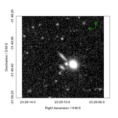

```r
magimageWCS(image)
```

A basic example of the lower level **profoundMakeSegim** versus the higher level **profoundProFound**:

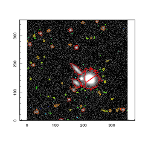

```r
out_segim=segim=profoundMakeSegim(image$imDat, magzero=30, pixscale=0.339, header=image$hdr, plot=TRUE)
```

```
## Running ProFound:
```

```
## Supplied image contains image and header components
```

```
## Supplied image is 356 x 356 pixels
```

```
## Extracted pixel scale from header provided: 0.339 asec/pixel
```

```
## Supplied image is 2.011 x 2.011 amin,  0.001 deg-sq
```

```
## Making initial sky map - 0.003 sec
```

```
##  - Sky statistics :
```

```
##    Min. 1st Qu.  Median    Mean 3rd Qu.    Max.
## -2.3257 -0.1157  0.5354  0.5499  1.0154  4.0443
```

```
##  - Sky-RMS statistics :
```

```
##    Min. 1st Qu.  Median    Mean 3rd Qu.    Max.
##   8.318   8.915   9.122   9.121   9.273   9.882
```

```
## Making initial segmentation image - 0.218 sec
```

```
##  - Running MakeSegim:
```

```
##  - Skipping making initial local estimate of the sky - User provided sky
```

```
##  - Skipping making initial local estimate of the sky RMS - User provided sky RMS
```

```
##  - Smoothing the image - 0.004 sec
```

```
##  - Watershed de-blending - 0.013 sec
```

```
##  - Skipping segmentation plot - plot set to FALSE
```

```
##  - Skipping making final local estimate of the sky - User provided sky
```

```
##  - Skipping making initial local estimate of the sky RMS - User provided sky RMS
```

```
##  - Skipping segmentation statistics - segstats set to FALSE or no segments
```

```
##  - MakeSegim is finished! - 0.043 sec
```

```
## Doing initial aggressive dilation - 0.263 sec
```

```
##  - Running MakeSegimDilate:
```

```
##  - Dilating segments - 0.001 sec
```

```
##  - Skipping segmentation statistics - segstats set to FALSE
```

```
##  - profoundMakeSegimDilate is finished! - 0.039 sec
```

```
## Making better sky map - 0.304 sec
```

```
##  - Sky statistics :
```

```
##     Min.  1st Qu.   Median     Mean  3rd Qu.     Max.
## -2.32792 -0.73111 -0.42721 -0.45022 -0.03966  0.41956
```

```
##  - Sky-RMS statistics :
```

```
##    Min. 1st Qu.  Median    Mean 3rd Qu.    Max.
##   8.317   8.697   8.799   8.822   8.982   9.199
```

```
## Calculating initial segstats - 0.491 sec
```

```
## Doing dilations:
```

```
## Iteration 1 of 6 - 0.533 sec
```

```
##  - Running MakeSegimDilate:
```

```
##  - Dilating segments - 0.002 sec
```

```
##  - Calculating segstats - 0.018 sec
```

```
##  - profoundMakeSegimDilate is finished! - 0.055 sec
```

```
## Iteration 2 of 6 - 0.589 sec
```

```
##  - Running MakeSegimDilate:
```

```
##  - Dilating segments - 0.002 sec
```

```
##  - Calculating segstats - 0.019 sec
```

```
##  - profoundMakeSegimDilate is finished! - 0.14 sec
```

```
## Iteration 3 of 6 - 0.731 sec
```

```
##  - Running MakeSegimDilate:
```

```
##  - Dilating segments - 0.001 sec
```

```
##  - Calculating segstats - 0.015 sec
```

```
##  - profoundMakeSegimDilate is finished! - 0.056 sec
```

```
## Iteration 4 of 6 - 0.79 sec
```

```
##  - Running MakeSegimDilate:
```

```
##  - Dilating segments - 0.002 sec
```

```
##  - Calculating segstats - 0.018 sec
```

```
##  - profoundMakeSegimDilate is finished! - 0.063 sec
```

```
## Iteration 5 of 6 - 0.855 sec
```

```
##  - Running MakeSegimDilate:
```

```
##  - Dilating segments - 0.002 sec
```

```
##  - Calculating segstats - 0.02 sec
```

```
##  - profoundMakeSegimDilate is finished! - 0.071 sec
```

```
## Iteration 6 of 6 - 0.927 sec
```

```
##  - Running MakeSegimDilate:
```

```
##  - Dilating segments - 0.002 sec
```

```
##  - Calculating segstats - 0.02 sec
```

```
##  - profoundMakeSegimDilate is finished! - 0.078 sec
```

```
## Finding CoG convergence - 1.007 sec
```

```
## Constructing final segim - 1.01 sec
```

```
## Doing final aggressive dilation - 1.067 sec
```

```
##  - Running MakeSegimDilate:
```

```
##  - Dilating segments - 0.001 sec
```

```
##  - Skipping segmentation statistics - segstats set to FALSE
```

```
##  - profoundMakeSegimDilate is finished! - 0.028 sec
```

```
## Making final sky map - 1.097 sec
```

```
##  - Sky statistics :
```

```
##    Min. 1st Qu.  Median    Mean 3rd Qu.    Max.
## -2.3270 -0.7348 -0.5039 -0.4977 -0.1780  0.5313
```

```
##  - Sky-RMS statistics :
```

```
##    Min. 1st Qu.  Median    Mean 3rd Qu.    Max.
##   8.324   8.660   8.779   8.798   8.969   9.195
```

```
## Calculating final segstats for 86 objects - 1.257 sec
```

```
##  - magzero = 30
```

```
##  - gain = NULL (ignored)
```

```
##  - pixscale = 0.339
```

```
##  - rotstats = FALSE
```

```
##  - boundstats = FALSE
```

```
## Plotting segments - 1.312 sec
```

```
## ProFound is finished! - 2.809 sec
```

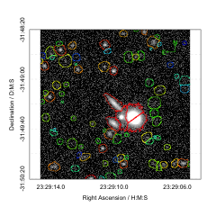

```r
out_profound=profoundProFound(image, magzero=30, verbose=TRUE, plot=TRUE)
```

Notice in the two outputs (the first being **profoundMakeSegim**, the second being **profoundProFound**) that some segment have converged quickly (i.e. not grown much) but others have expanded a lot in order to capture all the flux present. **profoundProFound** in default mode with modern survey imaging data tends to extract very close to a true total magnitude, without too much error introduced by sky noise (a consequence of over-growing apertures).

Because it was run in verbose mode, the major **profoundProFound** steps mentioned above were printed out. For large images (a few thousand by a few thousand pixels plus) this is useful since it can take a few minutes to run with all the bells and whistles turned on, and it is nice to see it making progress. Note for more than a couple of hundred sources, you almost certainly do not want to plot the output, since this will be slow.

Note because we parsed **profoundProFound** a header we have RA and Dec coordinates in the photometric properties data-frame. We also parsed the appropriate magnitude zero-point and pixel scale so the mag properties are correctly scaled, and R/R50/R90 are in arc-seconds rather than pixels. It is is worth checking the output:

```r
out_profound$segstats[1:10,]
```

```
##    segID uniqueID      xcen       ycen  xmax  ymax    RAcen    Deccen
## 1      1   222149 220.79105 148.792517 221.5 148.5 352.2866 -31.82505
## 2      2   227142 226.54757 140.893807 226.5 141.5 352.2860 -31.82579
## 3      3   194148 194.58182 147.245430 193.5 147.5 352.2895 -31.82519
## 4      4   122001 120.67586   2.229448 121.5   0.5 352.2977 -31.83885
## 5      5   175133 174.83841 132.824109 174.5 132.5 352.2917 -31.82655
## 6      6   178179 177.03286 179.329142 177.5 178.5 352.2915 -31.82217
## 7      7   175257 174.68049 257.602867 174.5 256.5 352.2918 -31.81480
## 8      8   155320 153.90857 319.910944 154.5 319.5 352.2941 -31.80894
## 9      9   149074 148.52417  73.628734 148.5  73.5 352.2947 -31.83213
## 10    10    48308  48.11695 307.182775  47.5 307.5 352.3058 -31.81013
##       RAmax    Decmax        sep        flux      mag     cenfrac
## 1  352.2866 -31.82508 0.25998956 2790717.014 13.88571 0.033702410
## 2  352.2860 -31.82574 0.20613114 1175345.490 14.82459 0.028589705
## 3  352.2897 -31.82517 0.37675542   71955.949 17.85733 0.024069923
```

[output cut: 84 more lines]

Next we will check the before and after photometry for the brightest 40 sources (the lists differ a bit in detail due to the different sky estimation routines used):

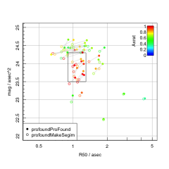

```r
magplot(out_segim$segstats[1:40,c("R50", "SB_N90")], col=hsv(magmap(out_segim$segstats$axrat, flip=TRUE)$map), log='x', xlim=c(0.4,5), ylim=c(22,25), grid=TRUE, xlab='R50 / asec', ylab='mag / asec^2')
points(out_profound$segstats[1:40,c("R50", "SB_N90")], col=hsv(magmap(out_segim$segstats$axrat, flip=TRUE)$map), pch=16)
arrows(out_segim$segstats$R50[1:40], out_segim$segstats$SB_N90[1:40], out_profound$segstats$R50[1:40], out_profound$segstats$SB_N90[1:40], col='lightgrey', length=0)
rect(0.9, 23.5, 1.3, 24.3)
legend('bottomleft', legend=c('profoundProFound', 'profoundMakeSegim'), pch=c(16,1))
magbar('topright', title='Axrat', titleshift=1)
```

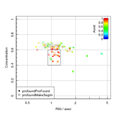

```r
magplot(out_segim$segstats[1:40,c("R50", "con")], col=hsv(magmap(out_segim$segstats$axrat, flip=TRUE)$map), log='x', xlim=c(0.4,5), ylim=c(0,1), grid=TRUE, xlab='R50 / asec', ylab='Concentration')
points(out_profound$segstats[1:40,c("R50", "con")], col=hsv(magmap(out_segim$segstats$axrat, flip=TRUE)$map), pch=16)
arrows(out_segim$segstats$R50[1:40], out_segim$segstats$con[1:40], out_profound$segstats$R50[1:40], out_profound$segstats$con[1:40], col='lightgrey', length=0)
rect(0.9, 0.4, 1.3, 0.6)
legend('bottomleft', legend=c('profoundProFound', 'profoundMakeSegim'), pch=c(16,1))
magbar('topright', title='Axrat', titleshift=1)
```

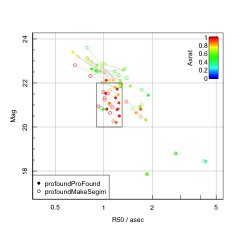

```r
magplot(out_segim$segstats[1:40,c("R50", "mag")], col=hsv(magmap(out_segim$segstats$axrat, flip=TRUE)$map), log='x', xlim=c(0.4,5), ylim=c(17,24), grid=TRUE, xlab='R50 / asec', ylab='Mag')
points(out_profound$segstats[1:40,c("R50", "mag")], col=hsv(magmap(out_segim$segstats$axrat, flip=TRUE)$map), pch=16)
arrows(out_segim$segstats$R50[1:40], out_segim$segstats$mag[1:40], out_profound$segstats$R50[1:40], out_profound$segstats$mag[1:40], col='lightgrey', length=0)
rect(0.9, 20, 1.3, 22)
legend('bottomleft', legend=c('profoundProFound', 'profoundMakeSegim'), pch=c(16,1))
magbar('topright', title='Axrat', titleshift=1)
```

It is notable that low surface brightness objects are seen to systematically grow when processing the image with **profoundProFound**. The box represents the location of likely stars, where redder objects are more circular sources. It is clear that **profoundProFound** moves stars onto a more uniform value of R50 (remember for a Gaussian PSF FWHM=2*R50).

The **profoundProFound** function also returns a sky and sky RMS image matched to the input image:

```
## [1] "Summary of used sample:"
##    Min. 1st Qu.  Median    Mean 3rd Qu.    Max.
## -2.3270 -0.7348 -0.5039 -0.4977 -0.1780  0.5313
## [1] "sd / 1-sig / 2-sig range:"
## [1] 0.5001919 0.4446320 1.1021306
## [1] "Plotting 126736 out of 126736 (100%) data points (0 < xlo & 0 > xhi)"
```

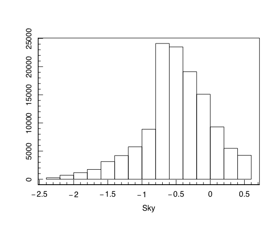

```r
maghist(out_profound$sky, xlab='Sky')
```

```
## [1] "Summary of used sample:"
##    Min. 1st Qu.  Median    Mean 3rd Qu.    Max.
##   8.324   8.660   8.779   8.798   8.969   9.195
## [1] "sd / 1-sig / 2-sig range:"
## [1] 0.1922451 0.2086032 0.3505592
## [1] "Plotting 126736 out of 126736 (100%) data points (0 < xlo & 0 > xhi)"
```

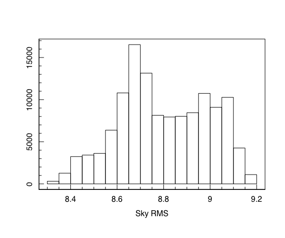

```r
maghist(out_profound$skyRMS, xlab='Sky RMS')
```

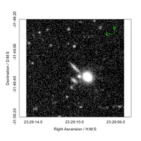

```r
magimageWCS(image)
```

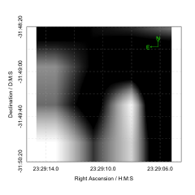

```r
magimageWCS(out_profound$sky, image$hdr)
```

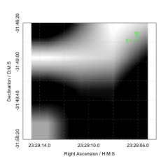

```r
magimageWCS(out_profound$skyRMS, image$hdr)
```

The background mask we used here (the default 100x100 option) looks to be pretty good, with not much correlation between the image and the sky map. However, even with a slightly too small sky grid the photometric outputs should be mostly pretty robust- differing by at worst a couple of counts per pixel. This is much less than the typical sky RMS (roughly 9 throughout).

```
## [1] "Summary of used sample:"
##      Min.   1st Qu.    Median      Mean   3rd Qu.      Max.
## 0.0004218 0.1313115 0.2107956 0.2453530 0.3010744 0.8381362
## [1] "sd / 1-sig / 2-sig range:"
## [1] 0.1739166 0.1431703 0.3550237
## [1] "Plotting 86 out of 86 (100%) data points (0 < xlo & 0 > xhi)"
```

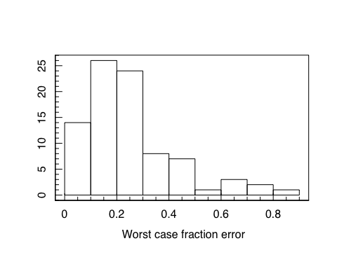

```r
maghist(out_profound$segstats[,'N100']/out_profound$segstats[,'flux'], xlab=' Worst case fraction error')
```

In summary, you probably want to use **profoundProFound**, unless you really know what you are doing and are feeling a bit adventurous!

## ProFound Flags

**ProFound** offers a few useful flags that will help extract high fidelity photometry. To access the boundary flags we have to set boundstats=TRUE when we run **ProFound**:

```r
out_profound=profoundProFound(image, magzero=30, verbose=TRUE, boundstats=TRUE)
```

```
## Running ProFound:
```

```
## Supplied image contains image and header components
```

```
## Supplied image is 356 x 356 pixels
```

```
## Extracted pixel scale from header provided: 0.339 asec/pixel
```

```
## Supplied image is 2.011 x 2.011 amin,  0.001 deg-sq
```

```
## Making initial sky map - 0.002 sec
```

```
##  - Sky statistics :
```

```
##    Min. 1st Qu.  Median    Mean 3rd Qu.    Max.
## -2.3257 -0.1157  0.5354  0.5499  1.0154  4.0443
```

```
##  - Sky-RMS statistics :
```

```
##    Min. 1st Qu.  Median    Mean 3rd Qu.    Max.
##   8.318   8.915   9.122   9.121   9.273   9.882
```

```
## Making initial segmentation image - 0.214 sec
```

```
##  - Running MakeSegim:
```

```
##  - Skipping making initial local estimate of the sky - User provided sky
```

```
##  - Skipping making initial local estimate of the sky RMS - User provided sky RMS
```

```
##  - Smoothing the image - 0.005 sec
```

```
##  - Watershed de-blending - 0.013 sec
```

```
##  - Skipping segmentation plot - plot set to FALSE
```

```
##  - Skipping making final local estimate of the sky - User provided sky
```

```
##  - Skipping making initial local estimate of the sky RMS - User provided sky RMS
```

```
##  - Skipping segmentation statistics - segstats set to FALSE or no segments
```

```
##  - MakeSegim is finished! - 0.044 sec
```

```
## Doing initial aggressive dilation - 0.26 sec
```

```
##  - Running MakeSegimDilate:
```

```
##  - Dilating segments - 0.001 sec
```

```
##  - Skipping segmentation statistics - segstats set to FALSE
```

```
##  - profoundMakeSegimDilate is finished! - 0.04 sec
```

```
## Making better sky map - 0.301 sec
```

```
##  - Sky statistics :
```

```
##     Min.  1st Qu.   Median     Mean  3rd Qu.     Max.
## -2.32792 -0.73111 -0.42721 -0.45022 -0.03966  0.41956
```

```
##  - Sky-RMS statistics :
```

```
##    Min. 1st Qu.  Median    Mean 3rd Qu.    Max.
##   8.317   8.697   8.799   8.822   8.982   9.199
```

```
## Calculating initial segstats - 0.487 sec
```

```
## Doing dilations:
```

```
## Iteration 1 of 6 - 0.527 sec
```

```
##  - Running MakeSegimDilate:
```

```
##  - Dilating segments - 0.002 sec
```

```
##  - Calculating segstats - 0.02 sec
```

```
##  - profoundMakeSegimDilate is finished! - 0.054 sec
```

```
## Iteration 2 of 6 - 0.582 sec
```

```
##  - Running MakeSegimDilate:
```

```
##  - Dilating segments - 0.002 sec
```

```
##  - Calculating segstats - 0.02 sec
```

```
##  - profoundMakeSegimDilate is finished! - 0.195 sec
```

```
## Iteration 3 of 6 - 0.78 sec
```

```
##  - Running MakeSegimDilate:
```

```
##  - Dilating segments - 0.002 sec
```

```
##  - Calculating segstats - 0.016 sec
```

```
##  - profoundMakeSegimDilate is finished! - 0.056 sec
```

```
## Iteration 4 of 6 - 0.837 sec
```

```
##  - Running MakeSegimDilate:
```

```
##  - Dilating segments - 0.002 sec
```

```
##  - Calculating segstats - 0.018 sec
```

```
##  - profoundMakeSegimDilate is finished! - 0.064 sec
```

```
## Iteration 5 of 6 - 0.904 sec
```

```
##  - Running MakeSegimDilate:
```

```
##  - Dilating segments - 0.002 sec
```

```
##  - Calculating segstats - 0.019 sec
```

```
##  - profoundMakeSegimDilate is finished! - 0.067 sec
```

```
## Iteration 6 of 6 - 0.974 sec
```

```
##  - Running MakeSegimDilate:
```

```
##  - Dilating segments - 0.001 sec
```

```
##  - Calculating segstats - 0.019 sec
```

```
##  - profoundMakeSegimDilate is finished! - 0.074 sec
```

```
## Finding CoG convergence - 1.051 sec
```

```
## Constructing final segim - 1.054 sec
```

```
## Doing final aggressive dilation - 1.111 sec
```

```
##  - Running MakeSegimDilate:
```

```
##  - Dilating segments - 0.001 sec
```

```
##  - Skipping segmentation statistics - segstats set to FALSE
```

```
##  - profoundMakeSegimDilate is finished! - 0.028 sec
```

```
## Making final sky map - 1.14 sec
```

```
##  - Sky statistics :
```

```
##    Min. 1st Qu.  Median    Mean 3rd Qu.    Max.
## -2.3270 -0.7348 -0.5039 -0.4977 -0.1780  0.5313
```

```
##  - Sky-RMS statistics :
```

```
##    Min. 1st Qu.  Median    Mean 3rd Qu.    Max.
##   8.324   8.660   8.779   8.798   8.969   9.195
```

```
## Calculating final segstats for 86 objects - 1.299 sec
```

```
##  - magzero = 30
```

```
##  - gain = NULL (ignored)
```

```
##  - pixscale = 0.339
```

```
##  - rotstats = FALSE
```

```
##  - boundstats = TRUE
```

```
## Skipping segmentation plot - plot set to FALSE
```

```
## ProFound is finished! - 1.521 sec
```

The output we get is in segstats is useful, telling us whether or not an object is isolated:

```r
out_profound$segstats[1:10,c("Nedge", "Nsky", "Nobject", "Nborder", "edge_frac", "edge_excess", "flag_border")]
```

```
##    Nedge Nsky Nobject Nborder edge_frac edge_excess flag_border
## 1    181  103      78       0 0.5690608   1.4825964           0
## 2    187  141      46       0 0.7540107   1.4492189           0
## 3    183   57     126       0 0.3114754   1.4815620           0
## 4     55   30       0      25 0.5454545   0.9944579           1
## 5    114   63      51       0 0.5526316   1.0826823           0
## 6    138  108      30       0 0.7826087   0.9874888           0
## 7     58   58       0       0 1.0000000   0.9114713           0
## 8     65   58       7       0 0.8923077   0.8727323           0
## 9     58   58       0       0 1.0000000   0.8901146           0
## 10    75   59      16       0 0.7866667   0.9167230           0
```

The edge_frac column is simply Nsky/Nedge (the number of segment edge pixels purely touching sky divided by the number of pixels in the segment edge). Where it is 1 the segment must be well isolated, because none of its outer pixels are touching either an image boundary or another object.

We can easily plot the isolated segments and the non-isolated segments:

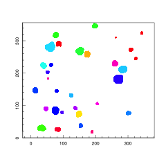

```r
magimage(out_profound$segim*(out_profound$segim %in% out_profound$segstats[out_profound$segstats$edge_frac==1,"segID"]), col=c(0,rainbow(100)))
```

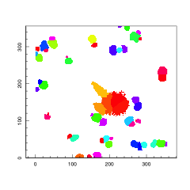

```r
magimage(out_profound$segim*(out_profound$segim %in% out_profound$segstats[out_profound$segstats$edge_frac!=1,"segID"]), col=c(0,rainbow(100)))
```

You might be more interested in removing segments touching an image edge:

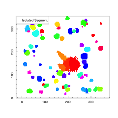

```r
magimage(out_profound$segim*(out_profound$segim %in% out_profound$segstats[out_profound$segstats$Nborder==0,"segID"]), col=c(0,rainbow(100)))
legend('topleft',legend='Isolated Segment')
```

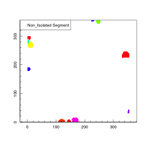

```r
magimage(out_profound$segim*(out_profound$segim %in% out_profound$segstats[out_profound$segstats$Nborder>0,"segID"]), col=c(0,rainbow(100)))
legend('topleft',legend='Non_Isolated Segment')
```

The edge_excess column tells us how elliptical or non-elliptical the segments are. Generally values less than 1 are probably fairly sensible looking segments (i.e. ellipses). Larger than this and the segments might have weird gemoetry:

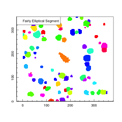

```r
magimage(out_profound$segim*(out_profound$segim %in% out_profound$segstats[out_profound$segstats$edge_excess<1,"segID"]), col=c(0,rainbow(100)))
legend('topleft',legend='Fairly Elliptical Segment')
```

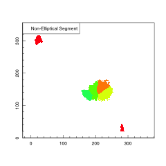

```r
magimage(out_profound$segim*(out_profound$segim %in% out_profound$segstats[out_profound$segstats$edge_excess>1,"segID"]), col=c(0,rainbow(100)))
legend('topleft',legend='Non-Elliptical Segment')
```

The flag_border column tells us which border of the image the segment touches. The bottom of the image is flagged 1, left=2, top=4 and right=8. A summed combination of these flags indicate the segment is in a corner touching two borders: bottom-left=3, top-left=6, top-right=12, bottom-right=9. In our case we can see we should find segments touching the bottom, left and top of the image:

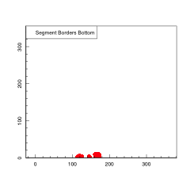

```r
magimage(out_profound$segim*(out_profound$segim %in% out_profound$segstats[out_profound$segstats$flag_border==1,"segID"]), col=c(0,rainbow(100)))
legend('topleft',legend='Segment Borders Bottom')
```

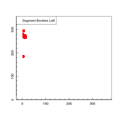

```r
magimage(out_profound$segim*(out_profound$segim %in% out_profound$segstats[out_profound$segstats$flag_border==2,"segID"]), col=c(0,rainbow(100)))
legend('topleft',legend='Segment Borders Left')
```

```r
magimage(out_profound$segim*(out_profound$segim %in% out_profound$segstats[out_profound$segstats$flag_border==4,"segID"]), col=c(0,rainbow(100)))
```

```
## [1] "Too many same valued pixels: turning off magmap scaling!"
```

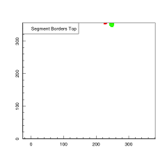

```r
legend('topleft',legend='Segment Borders Top')
```

Depending on your science requirements, users might want to make use of some or all of these useful flags. Practically the most useful flag is probably edge_frac, where values above 0.8 are usually a good cut off for fairly reliable photometry (i.e. the confused or missing flux is the sub-dominant form of error), but this cannot be treated as a guarantee!

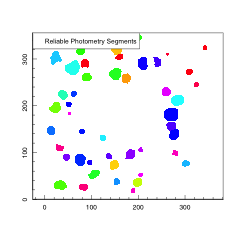

```r
magimage(out_profound$segim*(out_profound$segim %in% out_profound$segstats[out_profound$segstats$edge_frac>0.8,"segID"]), col=c(0,rainbow(100)))
legend('topleft',legend='Reliable Photometry Segments')
```

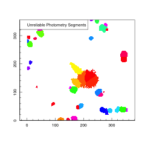

```r
magimage(out_profound$segim*(out_profound$segim %in% out_profound$segstats[out_profound$segstats$edge_frac<0.8,"segID"]), col=c(0,rainbow(100)))
legend('topleft',legend='Unreliable Photometry Segments')
```

## Advanced ProFound Usage

The way **ProFound** handles the various inputs allows for great flexibility and power. AS an example, it is fairly trivial to run it in a mode where you can extract multiband photometry in pixel matched data. AS a pseudo code example imagine you have 3 pixel matched 2k*2K J/H/K band images with the same magnitude zero points. You can use the objects detected in, say, the K band to extract photometry in the others:

```r
pro_det_K=profoundProFound(image=Kim)
```

### Total Photometry

We can then extract matching photometry. Note that in practice pro_K_tot_fix = pro_det_K (since the K band was our detection band already), but we psuedo re-run it for clarity.

```r
pro_J_tot_fix=profoundProFound(image=Jim, segim=pro_det_K$segim, iters=0)
pro_H_tot_fix=profoundProFound(image=Him, segim=pro_det_K$segim, iters=0)
pro_K_tot_fix=profoundProFound(image=Kim, segim=pro_det_K$segim, iters=0)
```

A second option is to allow each target band to dynamically dilate based on the original segmentation map. The might help in situations where the target image PSFs are quite mismatched. The dynamic dilation will ensure close to total magnitudes regardless of the differing PSFs. Note that in practice pro_K_tot_dil = pro_det_K (since the K band was our detection band already), but we psuedo re-run it for clarity.

```r
pro_J_tot_dil=profoundProFound(image=Jim, segim=pro_det_K$segim_orig, objects=pro_det_K$objects)
pro_H_tot_dil=profoundProFound(image=Him, segim=pro_det_K$segim_orig, objects=pro_det_K$objects)
pro_K_tot_dil=profoundProFound(image=Kim, segim=pro_det_K$segim_orig, objects=pro_det_K$objects)
```

### Colour Photometry

The above options would extract close to total photometry given the K-band detection segments. You often find better colours running with the high surface brightness non-dilated segmentation map, which is also returned by **ProFound**. In this case you would need to re-run the K too. Notice we also pass the **objects** matrix to ProFound. This ensures a better sky estimation, since we are now using the brighter inner part of detected objects to extract colour photometry, but we want to know the location of the full object to obtain a good sky estimate.

```r
pro_J_col_fix=profoundProFound(image=Jim, segim=pro_det_K$segim_orig, objects=pro_det_K$objects, iters=0)
pro_H_col_fix=profoundProFound(image=Him, segim=pro_det_K$segim_orig, objects=pro_det_K$objects, iters=0)
pro_K_col_fix=profoundProFound(image=Kim, segim=pro_det_K$segim_orig, objects=pro_det_K$objects, iters=0)
```